# Neo4j_tuto

**Main Algorithms** : https://neo4j.com/docs/graph-algorithms/current/introduction/

**Example of notebook** : https://nicolewhite.github.io/neo4j-jupyter/hello-world.html

**Getting started with Neo4j and Python** : https://marcobonzanini.com/2015/04/06/getting-started-with-neo4j-and-python/

**Basic in Cypher** : https://neo4j.com/developer/cypher-query-language/

**Cypher case study Tour de France** : https://neo4j.com/graphgist/modeling-the-tour-de-france-2014-in-a-neo4j-graph-database

**Algorithms** [Degree Centrality / Eigenvector Centrality / Katz Centrality / PageRank / HITS Hubs and Authorities / Closeness Centrality / Betweenness Centrality] : https://aksakalli.github.io/2017/07/17/network-centrality-measures-and-their-visualization.html

# 1. Set up connection with Neo4j

```python
from py2neo import Graph

graph = Graph("bolt://localhost:7687", user="neo4j", password="france")
graph.delete_all()
```

# 2. Load CSV file into Neo4j database

### A. 1st example with *Riders*

```python
import pandas as pd

data_rider = pd.read_csv('https://raw.githubusercontent.com/inserpio/tour-de-france-2014/master/tour-de-france-2014-0001-teams-and-riders.csv')
data_rider.head(3)
```

|  | RACE_ID | RACE_NAME | RACE_YEAR | RACE_FROM | RACE_TO | RACE_DISTANCE | RACE_NUMBER_OF_STAGES | RACE_EDITION | RACE_WEBSITE | TEAM_ID | TEAM_NAME | TEAM_COUNTRY | TEAM_MANAGERS | RIDER_NUMBER | RIDER_NAME | RIDER_COUNTRY | RIDER_INFO |
| --- | --- | --- | --- | --- | --- | --- | --- | --- | --- | --- | --- | --- | --- | --- | --- | --- | --- |
| 0 | 1 | TOUR DE FRANCE | 2014 | 05/07/2014 | 27/07/2014 | 3663.5 | 21 | 101 | http://www.letour.com/le-tour/2014/us/ | 1 | TEAM SKY | GBR | PORTAL Nicolas, KNAVEN Servais | 1 | FROOME Christopher | GBR | http://www.letour.com/le-tour/2014/us/riders/t... |
| 1 | 1 | TOUR DE FRANCE | 2014 | 05/07/2014 | 27/07/2014 | 3663.5 | 21 | 101 | http://www.letour.com/le-tour/2014/us/ | 1 | TEAM SKY | GBR | PORTAL Nicolas, KNAVEN Servais | 2 | EISEL Bernhard | AUT | http://www.letour.com/le-tour/2014/us/riders/t... |
| 2 | 1 | TOUR DE FRANCE | 2014 | 05/07/2014 | 27/07/2014 | 3663.5 | 21 | 101 | http://www.letour.com/le-tour/2014/us/ | 1 | TEAM SKY | GBR | PORTAL Nicolas, KNAVEN Servais | 3 | KIRYIENKA Vasili | BLR | http://www.letour.com/le-tour/2014/us/riders/t... |

```python
list(data_rider)
```

```
['RACE_ID',
 'RACE_NAME',
 'RACE_YEAR',
 'RACE_FROM',
 'RACE_TO',
 'RACE_DISTANCE',
 'RACE_NUMBER_OF_STAGES',
 'RACE_EDITION',
 'RACE_WEBSITE',
 'TEAM_ID',
 'TEAM_NAME',
 'TEAM_COUNTRY',
 'TEAM_MANAGERS',
 'RIDER_NUMBER',
 'RIDER_NAME',
 'RIDER_COUNTRY',
 'RIDER_INFO']
```

**Understand my queries** :

**Line 1** : load CSV file

**Line 2** : r:Race

- RACE_ID (id)
- RACE_NAME
- RACE_FROM
- RACE_TO
- RACE_EDITION
- RACE_DISTANCE
- RACE_NUMBER_OF_STAGES
- RACE_WEBSITE

**Line 3** : t:Team

- TEAM_ID (id)
- TEAM_NAME
- TEAM_COUNTRY
- TEAM_MANAGERS

**Line 4** : p:Rider

- RIDER_NUMBER (number)
- RIDER_NAME
- RIDER_COUNTRY

**Line 5** : Create link and bring information to links

```python
query_rider = """
LOAD CSV WITH HEADERS FROM "https://raw.githubusercontent.com/inserpio/tour-de-france-2014/master/tour-de-france-2014-0001-teams-and-riders.csv" AS csvLine
MERGE (r:Race { id: toInt(csvLine.RACE_ID), name: csvLine.RACE_NAME, from: csvLine.RACE_FROM, to: csvLine.RACE_TO, edition: csvLine.RACE_EDITION, distance: csvLine.RACE_DISTANCE, number_of_stages: csvLine.RACE_NUMBER_OF_STAGES, website: csvLine.RACE_WEBSITE })
MERGE (t:Team { id: toInt(csvLine.TEAM_ID), name: csvLine.TEAM_NAME, country: csvLine.TEAM_COUNTRY, sportingDirectors: csvLine.TEAM_MANAGERS })
MERGE (p:Rider { name: csvLine.RIDER_NAME, country: csvLine.RIDER_COUNTRY })
CREATE (t)-[:TAKES_PART_IN]->(r)<-[:TAKES_PART_IN { number: toInt(csvLine.RIDER_NUMBER), info: csvLine.RIDER_INFO }]-(p), (p)-[:RIDES_FOR { year: toInt(csvLine.RACE_YEAR) }]->(t);
"""
```

```python
graph.run(query_rider)
```

```
<py2neo.database.Cursor at 0x28c3e77ef60>
```

```python
from IPython.display import Image
Image(filename="pictures/Riders_links_info.gif")
```

[output not shown]

```python
#graph.delete_all()
```

### B. 2nd examples with *Etapes*

```python
import pandas as pd

data_etapes = pd.read_csv('https://raw.githubusercontent.com/inserpio/tour-de-france-2014/master/tour-de-france-2014-0002-stages.csv')
data_etapes.head(3)
```

|  | RACE_ID | STAGE_NUMBER | STAGE_TYPE | STAGE_DATE | STAGE_START | STAGE_START_COUNTRY | STAGE_START_LATITUDE | STAGE_START_LONGITUDE | STAGE_FINISH | STAGE_FINISH_COUNTRY | STAGE_FINISH_LATITUDE | STAGE_FINISH_LONGITUDE | STAGE_DISTANCE | STAGE_INFO |
| --- | --- | --- | --- | --- | --- | --- | --- | --- | --- | --- | --- | --- | --- | --- |
| 0 | 1 | 1 | Flat | 05/07/2014 | Leeds | ENG | 53.799722 | -1.549167 | Harrogate | ENG | 53.991000 | -1.539000 | 190.5 | http://www.letour.com/le-tour/2014/us/stage-1.... |
| 1 | 1 | 2 | Hilly | 06/07/2014 | York | ENG | 53.958333 | -1.080278 | Sheffield | ENG | 53.383611 | -1.466944 | 201.0 | http://www.letour.com/le-tour/2014/us/stage-2.... |
| 2 | 1 | 3 | Flat | 07/07/2014 | Cambridge | ENG | 52.205000 | 0.119000 | Londres | ENG | 51.507222 | -0.127500 | 155.0 | http://www.letour.com/le-tour/2014/us/stage-3.... |

```python
list(data_etapes)
```

```
['RACE_ID',
 'STAGE_NUMBER',
 'STAGE_TYPE',
 'STAGE_DATE',
 'STAGE_START',
 'STAGE_START_COUNTRY',
 'STAGE_START_LATITUDE',
 'STAGE_START_LONGITUDE',
 'STAGE_FINISH',
 'STAGE_FINISH_COUNTRY',
 'STAGE_FINISH_LATITUDE',
 'STAGE_FINISH_LONGITUDE',
 'STAGE_DISTANCE',
 'STAGE_INFO']
```

```python
query_etapes = """
LOAD CSV WITH HEADERS FROM "https://raw.githubusercontent.com/inserpio/tour-de-france-2014/master/tour-de-france-2014-0002-stages.csv" AS csvLine MATCH (r:Race { id: 1 })
MERGE (s:Stage { name: csvLine.STAGE_START + " / " + csvLine.STAGE_FINISH, number: toInt(csvLine.STAGE_NUMBER), type: csvLine.STAGE_TYPE, date: csvLine.STAGE_DATE, distance: toFloat(csvLine.STAGE_DISTANCE), info: csvLine.STAGE_INFO})
MERGE (cs: City { name: csvLine.STAGE_START, country: csvLine.STAGE_START_COUNTRY, lat: toFloat(csvLine.STAGE_START_LATITUDE), lon: toFloat(csvLine.STAGE_START_LONGITUDE) })
MERGE (cf: City { name: csvLine.STAGE_FINISH, country: csvLine.STAGE_FINISH_COUNTRY,  lat: toFloat(csvLine.STAGE_FINISH_LATITUDE), lon: toFloat(csvLine.STAGE_FINISH_LONGITUDE) })
CREATE (s)-[:IS_A_STAGE_OF]->(r), (s)-[:STARTS_FROM]->(cs), (s)-[:FINISHED_AT]->(cf);
"""
```

```python
graph.run(query_etapes)
```

```
<py2neo.database.Cursor at 0x28c4890c080>
```

```python
from IPython.display import Image
Image(filename="pictures/Etapes_links.gif")
```

[output not shown]

### C. 3rd examples with Climbs

```python
import pandas as pd

data_climbs = pd.read_csv('https://raw.githubusercontent.com/inserpio/tour-de-france-2014/master/tour-de-france-2014-0003-climbs.csv')
data_climbs.head(3)
```

|  | STAGE_NUMBER | STARTING_AT_KM | NAME | INITIAL_ALTITUDE | DISTANCE | AVERAGE_SLOPE | CATEGORY |
| --- | --- | --- | --- | --- | --- | --- | --- |
| 0 | 1 | 68.0 | Côte de Cray | 0 | 1.6 | 7.1 | 4 |
| 1 | 1 | 103.5 | Côte de Buttertubs | 0 | 4.5 | 6.8 | 3 |
| 2 | 1 | 129.5 | Côte de Griton Moor | 0 | 3.0 | 6.6 | 3 |

```python
list(data_climbs)
```

```
['STAGE_NUMBER',
 'STARTING_AT_KM',
 'NAME',
 'INITIAL_ALTITUDE',
 'DISTANCE',
 'AVERAGE_SLOPE',
 'CATEGORY']
```

```python
query_climbs = """
LOAD CSV WITH HEADERS FROM "https://raw.githubusercontent.com/inserpio/tour-de-france-2014/master/tour-de-france-2014-0003-climbs.csv" AS csvLine
MATCH (s:Stage { number: toInt(csvLine.STAGE_NUMBER) })
CREATE (s)-[:INCLUDES]->(c:Climb { startingAtKm: toFloat(csvLine.STARTING_AT_KM), name: csvLine.NAME, initialAltitude: toFloat(csvLine.INITIAL_ALTITUDE), averageSlope: toFloat(csvLine.AVERAGE_SLOPE), distance: toFloat(csvLine.DISTANCE), category: csvLine.CATEGORY });
"""
```

```python
graph.run(query_climbs)
```

```
<py2neo.database.Cursor at 0x28c4890ca90>
```

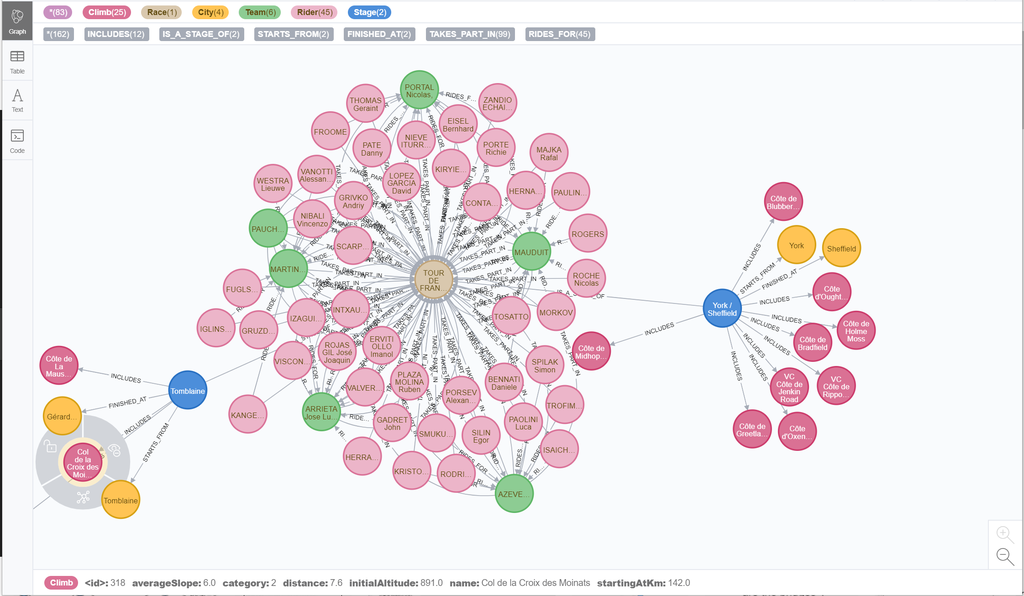

```python
Image(filename="pictures/climbs.PNG")
```

```python
import pandas as pd

data_intermediate_sprints = pd.read_csv('https://raw.githubusercontent.com/inserpio/tour-de-france-2014/master/tour-de-france-2014-0004-intermediate_sprints.csv')
data_intermediate_sprints.head(3)
```

|  | STAGE_NUMBER | AT_KM | CITY | COUNTRY | LATITUDE | LONGITUDE |
| --- | --- | --- | --- | --- | --- | --- |
| 0 | 1 | 77.0 | Newbiggin | ENG | 54.26929 | -2.00449 |
| 1 | 2 | 68.5 | Keighley | ENG | 53.86700 | -1.91100 |
| 2 | 3 | 108.0 | Epping Forest | ENG | 51.66000 | 0.05000 |

```python
query_intermediate_sprints = """
LOAD CSV WITH HEADERS FROM "https://raw.githubusercontent.com/inserpio/tour-de-france-2014/master/tour-de-france-2014-0003-climbs.csv" AS csvLine
MATCH (s:Stage { number: toInt(csvLine.STAGE_NUMBER) })
CREATE (s)-[:INCLUDES]->(c:Climb { startingAtKm: toFloat(csvLine.STARTING_AT_KM), name: csvLine.NAME, initialAltitude: toFloat(csvLine.INITIAL_ALTITUDE), averageSlope: toFloat(csvLine.AVERAGE_SLOPE), distance: toFloat(csvLine.DISTANCE), category: csvLine.CATEGORY });
"""
```

```python
graph.run(query_intermediate_sprints)
```

```
<py2neo.database.Cursor at 0x28c489fa978>
```

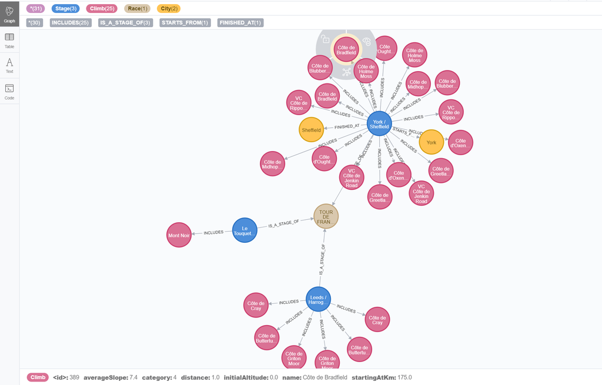

```python
Image(filename="pictures/intermediate_sprints.PNG")
```

# 3. Queries in Cypher

https://github.com/mneedham/strava/blob/master/Strava.ipynb

### How many teams per country will take part in TDF 2014?

```python
questions_teams_per_country = """
MATCH (t:Team) RETURN DISTINCT t.country, collect(t.name), count(t.name) AS teamsPerCountry ORDER BY teamsPerCountry DESC;
"""
```

```python
response_teams_per_country = graph.run(questions_teams_per_country)

for d in response_teams_per_country:
    print(d)
```

```
<Record t.country='FRA\xa0' collect(t.name)=['AG2R LA MONDIALE', 'FDJ.FR', 'TEAM EUROPCAR', 'COFIDIS, SOLUTIONS CREDITS', 'BRETAGNE - SECHE ENVIRONNEMENT'] teamsPerCountry=5>
<Record t.country='USA\xa0' collect(t.name)=['GARMIN - SHARP', 'BMC RACING TEAM', 'TREK FACTORY RACING'] teamsPerCountry=3>
<Record t.country='RUS\xa0' collect(t.name)=['TEAM KATUSHA', 'TINKOFF – SAXO'] teamsPerCountry=2>
<Record t.country='ITA\xa0' collect(t.name)=['CANNONDALE', 'LAMPRE - MERIDA'] teamsPerCountry=2>
<Record t.country='NED\xa0' collect(t.name)=['BELKIN PRO CYCLING', 'TEAM GIANT - SHIMANO'] teamsPerCountry=2>
<Record t.country='BEL\xa0' collect(t.name)=['OMEGA PHARMA - QUICK STEP', 'LOTTO – BELISOL'] teamsPerCountry=2>
<Record t.country='GBR\xa0' collect(t.name)=['TEAM SKY'] teamsPerCountry=1>
<Record t.country='ESP\xa0' collect(t.name)=['MOVISTAR TEAM'] teamsPerCountry=1>
<Record t.country='KAZ\xa0' collect(t.name)=['ASTANA PRO TEAM'] teamsPerCountry=1>
<Record t.country='AUS\xa0' collect(t.name)=['ORICA GREENEDGE'] teamsPerCountry=1>
<Record t.country='SUI\xa0' collect(t.name)=['IAM CYCLING'] teamsPerCountry=1>
<Record t.country='GER\xa0' collect(t.name)=['TEAM NETAPP – ENDURA'] teamsPerCountry=1>
```

```python
graph.run(questions_teams_per_country).to_data_frame()
```

|  | collect(t.name) | t.country | teamsPerCountry |
| --- | --- | --- | --- |
| 0 | [AG2R LA MONDIALE, FDJ.FR, TEAM EUROPCAR, COFI... | FRA | 5 |
| 1 | [GARMIN - SHARP, BMC RACING TEAM, TREK FACTORY... | USA | 3 |
| 2 | [TEAM KATUSHA, TINKOFF – SAXO] | RUS | 2 |
| 3 | [CANNONDALE, LAMPRE - MERIDA] | ITA | 2 |
| 4 | [BELKIN PRO CYCLING, TEAM GIANT - SHIMANO] | NED | 2 |
| 5 | [OMEGA PHARMA - QUICK STEP, LOTTO – BELISOL] | BEL | 2 |
| 6 | [TEAM SKY] | GBR | 1 |
| 7 | [MOVISTAR TEAM] | ESP | 1 |
| 8 | [ASTANA PRO TEAM] | KAZ | 1 |
| 9 | [ORICA GREENEDGE] | AUS | 1 |
| 10 | [IAM CYCLING] | SUI | 1 |
| 11 | [TEAM NETAPP – ENDURA] | GER | 1 |

### How many riders per country will take part in TDF2014?

```python
questions_riders_per_country = """
MATCH (r:Rider) RETURN DISTINCT r.country, count(r.name) AS ridersPerCountry ORDER BY ridersPerCountry DESC;
"""
```

```python
graph.run(questions_riders_per_country).to_data_frame().head()
```

|  | r.country | ridersPerCountry |
| --- | --- | --- |
| 0 | FRA | 44 |
| 1 | ESP | 20 |
| 2 | ITA | 17 |
| 3 | NED | 17 |
| 4 | AUS | 10 |

# NetworkX

**Goal**: Graph algorithms are used to compute metrics for graphs, nodes, or relationships. Provide insights on relevant

```
- Entities in the graph (centralities, ranking)
- Inherent structures like communities (community-detection, graph-partitioning, clustering).
```

**How does it work?** : Many graph algorithms are **iterative approaches that frequently traverse the graph for the computation using random walks, breadth-first or depth-first searches, or pattern matching.**

**Hard?**: Due to the exponential growth of possible paths with increasing distance, many of the approaches also have high algorithmic complexity.

Fortunately, optimized algorithms exist that **utilize certain structures of the graph**, **memorize already explored parts**, and **parallelize operations**.

https://neo4j.com/docs/graph-algorithms/current/introduction/

#### 1. Centrality algorithms *determine the importance of distinct nodes in a network*

- **PageRank**
- **ArticleRank**
- **Betweenness Centrality**
- **Closeness Centrality**
- **Harmonic Centrality**
- **Eigenvector Centrality**
- **Degree Centrality**

#### 2. Community detection algorithms *evaluate how a group is clustered or partitioned, as well as its tendency to strengthen or break apart*

- **Louvain**
- **Label Propagation**
- **Connected Components**
- **Strongly Connected Components**
- **Triangle Counting / Clustering Coefficient**
- **Balanced Triads**

#### 3. Path finding algorithms *help find the shortest path or evaluate the availability and quality of routes*

- **Minimum Weight Spanning Tree**
- **Shortest Path**
- **Single Source Shortest Path**
- **All Pairs Shortest Path**
- **A***
- **Yen’s K-shortest paths**
- **Random Walk**

#### 4. Link Prediction algorithms *help determine the closeness of a pair of nodes. We would then use the computed scores as part of a link prediction solution*

- **Adamic Adar**
- **Common Neighbors**
- **Preferential Attachment**
- **Resource Allocation**
- **Same Community**
- **Total Neighbors**

### Symetric vs. Asymetric Graph

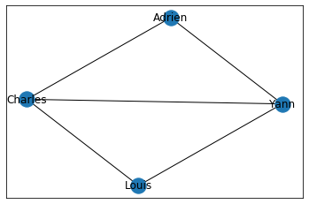

```python
my_network = [("Adrien", "Charles"), ("Charles", "Louis"), ("Charles", "Yann"), ("Yann", "Adrien"), ("Louis", "Yann")]

G_symmetric = nx.Graph()
G_asymmetric = nx.DiGraph()

for node in my_network:
    # Symetric Graph
    G_symmetric.add_edge(node[0],node[1])

    # Asymetric Graph
    G_asymmetric.add_edge(node[0],node[1])

nx.draw_networkx(G_symmetric)
```

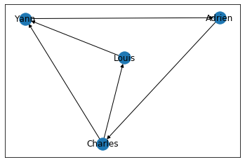

```python
nx.draw_networkx(G_asymmetric)
```

### Weighted Graph

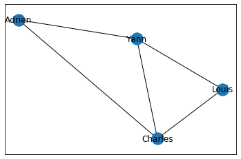

```python
my_network = [("Adrien", "Charles",2), ("Charles", "Louis",18), ("Charles", "Yann",30), ("Yann", "Adrien",5), ("Louis", "Yann", 11)]

G_weighted = nx.Graph()

for node in my_network:
    G_weighted.add_edge(node[0], node[1], weight=node[2])

nx.draw_networkx(G_weighted)
```

# Use Case Facebook

```python
PATH_FACEBOOK = "dataset/facebook_combined.txt"
G_fb = nx.read_edgelist(PATH_FACEBOOK, create_using = nx.Graph(), nodetype=int)
```

```python
print(nx.info(G_fb))
```

```
Name:
Type: Graph
Number of nodes: 4039
Number of edges: 88234
Average degree:  43.6910
```

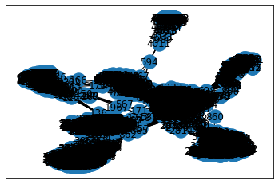

```python
nx.draw_networkx(G_fb)
```